# Bulk RNA-seq Analysis of CLL Dasatinib Response

SummarizedExperiment + edgeR/limma-voom Approach

Samuel Escudero, Ivon Sanchez, Karim Hamed

Universitat Pompeu Fabra

samuel.escudero01@estudiant.upf.edu

2026-05-25

# 1 Introduction

## 1.1 Biological context

Chronic lymphocytic leukemia (CLL) is a clinically heterogeneous hematological malignancy characterized by diverse responses to targeted treatments. Dasatinib, a second-generation tyrosine kinase inhibitor (TKI), represents a potential therapeutic strategy for patients with CLL. However, its clinical efficacy varies significantly between individuals. Blatte et al. (2021) employed RNA sequencing (RNA-seq) to characterize the transcriptional profiles of primary leukemia cells from treatment-naive CLL patients classified into two groups based on in vitro cytotoxicity assays: **responders** (dasatinib-sensitive) and **nonresponders** (dasatinib-resistant). Their primary goal was to discover gene expression signatures predictive of dasatinib sensitivity.

The RNAseq data generated by Blatte and colleagues were deposited at the Gene Expression Omnibus (GEO), publicly accessible under accession GSE151159.

## 1.2 Analytical approach: Why SummarizedExperiment + edgeR/limma-voom?

In this pipeline, we use the **SummarizedExperiment** container as our central data structure, combined with the **edgeR/limma-voom** framework for differential expression (DE) analysis. This is the approach taught in the IEO course at UPF and represents one of the most widely used frameworks in bulk RNA-seq analysis.

**Theory: The SummarizedExperiment object**

The `SummarizedExperiment` class from Bioconductor is designed to store rectangular matrices of experimental results (e.g., count matrices from RNA-seq). It keeps three critical pieces of information tightly coupled:

- `assays()` - one or more matrices (e.g., raw counts, logCPM, normalized values), where rows are genomic features (genes) and columns are samples
- `rowData()` - a DataFrame of gene-level annotations (Ensembl ID, biotype, gene symbol)
- `colData()` - a DataFrame of sample-level metadata (treatment condition, batch, clinical covariates)

This coupling ensures that whenever we subset genes or samples, all three components stay in sync, preventing the misalignment errors that plague manual matrix manipulation.

**Theory: Why edgeR + limma-voom instead of DESeq2?**

Both frameworks are statistically sound, but they model the data differently. DESeq2 models raw counts directly using a negative binomial distribution, while the edgeR/limma-voom approach first transforms counts into log-CPM values with precision weights (via `voom()`), then applies the powerful linear modeling framework of limma. The voom transformation estimates the mean-variance relationship and generates observation-level weights that stabilize the variance, allowing us to use standard linear models. This approach is particularly effective when we have moderate-to-large sample sizes and want to fit complex designs (e.g., paired samples, factorial designs, blocking). Benchmarking studies have shown that DESeq2 and limma-voom display comparable performance, with limma-voom being computationally faster and more flexible for complex experimental designs.

## 1.3 Libraries

```r
# --- Core Bioconductor packages ---
library(SummarizedExperiment) # Central data container
library(edgeR)                # DGEList, calcNormFactors, cpm, filterByExpr
library(limma)                # voom, lmFit, eBayes, topTable, makeContrasts

# --- Batch effect detection and correction ---
library(sva)                  # Surrogate Variable Analysis

# --- Functional enrichment ---
library(GOstats)              # Hypergeometric GO testing
library(org.Hs.eg.db)         # Human gene annotation database
library(AnnotationDbi)        # Interface to annotation resources
#library(fgsea)                # Fast Gene Set Enrichment Analysis

# --- Visualization and reporting ---
library(pheatmap)             # Heatmaps with clustering
library(RColorBrewer)         # Color palettes
library(ggplot2)              # Grammar of graphics
library(ggrepel)              # Non-overlapping text labels
library(dplyr)                # Data manipulation
library(tibble)               # rownames_to_column()
library(knitr)                # kable()
library(kableExtra)           # Table styling
```

# 2 Data Import and Initial Inspection

## 2.1 Loading the SummarizedExperiment

We load the `GSE151159.rds` file, which contains the complete dataset packaged as a `SummarizedExperiment` object. This object was assembled from GEO and includes raw gene-level counts, sample metadata, and gene annotations.

```r
# Load the SummarizedExperiment
# Adjust the path depending on your setup:
# Option A: from the IEOproject R package
# cll <- readRDS(file.path(system.file("extdata", package = "IEOproject"), "GSE151159.rds"))
# Option B: from the data/ directory (recommended for this repository)
cll <- readRDS("../data/GSE151159.rds")

# Inspect the object
cll
class: RangedSummarizedExperiment
dim: 25120 31
metadata(4): experimentData annotation ensemblVersion urlProcessedData
assays(1): counts
rownames(25120): 1 10 ... 9994 9997
rowData names(5): gene_id gene_biotype description gene_id_version
  symbol
colnames(31): SRR11844699 SRR11844700 ... SRR11844729 SRR11844730
colData names(46): title geo_accession ... patient's in vitro response
  to dasatinib:ch1 unified patient id, as used in the manuscript:ch1
```

**What we see**: The object contains 25120 genes across 31 samples, with the count matrix stored in `assays(cll)$counts`.

```r
# Examine the structure
cat("Assays available:", names(assays(cll)), "\n")
Assays available: counts
cat("Dimensions:", nrow(cll), "genes x", ncol(cll), "samples\n\n")
Dimensions: 25120 genes x 31 samples

# Peek at the count matrix
cat("First 5 genes x 3 samples of the count matrix:\n")
First 5 genes x 3 samples of the count matrix:
assays(cll)$counts[1:5, 1:3]
      SRR11844699 SRR11844700 SRR11844701
1              48          47          37
10              0           0           0
100          1167        1316         372
1000            2           0           0
10000        1019         890        2836
```

```r
# Sample metadata
cat("Sample-level metadata columns:\n")
Sample-level metadata columns:
cat(colnames(colData(cll)), sep = "\n")
title
geo_accession
status
submission_date
last_update_date
type
channel_count
source_name_ch1
organism_ch1
characteristics_ch1
characteristics_ch1.1
characteristics_ch1.2
characteristics_ch1.3
characteristics_ch1.4
characteristics_ch1.5
characteristics_ch1.6
molecule_ch1
extract_protocol_ch1
extract_protocol_ch1.1
taxid_ch1
description
description.1
description.2
description.3
description.4
data_processing
data_processing.1
data_processing.2
data_processing.3
data_processing.4
platform_id
data_row_count
instrument_model
library_selection
library_source
library_strategy
relation
relation.1
supplementary_file_1
batch:ch1
cell type:ch1
in vitro dasatinib treatment:ch1
patient diagnosis:ch1
patient id:ch1
patient's in vitro response to dasatinib:ch1
unified patient id, as used in the manuscript:ch1
```

```r
# Gene annotations
cat("\nGene-level annotation columns:\n")

Gene-level annotation columns:
cat(colnames(rowData(cll)), sep = "\n")
gene_id
gene_biotype
description
gene_id_version
symbol
cat("\nFirst 5 gene annotations:\n")

First 5 gene annotations:
head(as.data.frame(rowData(cll)), 5)
              gene_id   gene_biotype
1     ENSG00000121410 protein_coding
10    ENSG00000156006 protein_coding
100   ENSG00000196839 protein_coding
1000  ENSG00000170558 protein_coding
10000 ENSG00000117020 protein_coding
                                                          description
1              alpha-1-B glycoprotein [Source:HGNC Symbol;Acc:HGNC:5]
10           N-acetyltransferase 2 [Source:HGNC Symbol;Acc:HGNC:7646]
100             adenosine deaminase [Source:HGNC Symbol;Acc:HGNC:186]
1000                    cadherin 2 [Source:HGNC Symbol;Acc:HGNC:1759]
10000 AKT serine/threonine kinase 3 [Source:HGNC Symbol;Acc:HGNC:393]
         gene_id_version symbol
1     ENSG00000121410.11   A1BG
10     ENSG00000156006.4   NAT2
100   ENSG00000196839.12    ADA
1000   ENSG00000170558.8   CDH2
10000 ENSG00000117020.16   AKT3
```

## 2.2 Sample Classification: Defining Responders vs. Non-Responders

The original metadata uses `description.2` to encode treatment response. We create a clean binary factor `response2` with levels `NonResponder` and `Responder`, and remove ambiguous samples labeled “all”.

```r
# Examine the raw descriptions
cat("Raw sample descriptions:\n")
Raw sample descriptions:
table(colData(cll)$description.2)

          all_final_DESeq2~patient+treatment_all_countsNormalized.txt
                                                                    3
nonresponders_final_DESeq2~patient+treatment_all_countsNormalized.txt
                                                                   16
   responders_final_DESeq2~patient+treatment_all_countsNormalized.txt
                                                                   12

# Create clean response classification
desc2 <- colData(cll)$description.2
response_raw <- ifelse(
  grepl("^responders_final", desc2), "Responder",
  ifelse(grepl("^nonresponders_final", desc2), "NonResponder", NA)
)

colData(cll)$response2 <- factor(
  response_raw,
  levels = c("NonResponder", "Responder")
)

cat("\nClean response classification:\n")

Clean response classification:
table(colData(cll)$response2, useNA = "ifany")

NonResponder    Responder         <NA>
          16           12            3

# Remove samples with undefined response (labeled "all")
keep_samples <- !is.na(colData(cll)$response2)
cll <- cll[, keep_samples]

cat("\nAfter removing ambiguous samples:", ncol(cll), "samples retained\n")

After removing ambiguous samples: 28 samples retained
cat("  NonResponders:", sum(cll$response2 == "NonResponder"), "\n")
  NonResponders: 16
cat("  Responders:   ", sum(cll$response2 == "Responder"), "\n")
  Responders:    12
```

## 2.3 Export Shared Data (for Pipelines 2 and 3)

We export the count matrix and metadata as CSV files so that the Seurat (Pipeline 2) and Scanpy (Pipeline 3) approaches can consume the same preprocessed data without needing the `SummarizedExperiment` package.

```r
# Export counts
write.csv(as.data.frame(assays(cll)$counts),
          "../data/counts_matrix.csv", row.names = TRUE)

# Export sample metadata
write.csv(as.data.frame(colData(cll)),
          "../data/sample_metadata.csv", row.names = TRUE)

# Export gene metadata
write.csv(as.data.frame(rowData(cll)),
          "../data/gene_metadata.csv", row.names = TRUE)

cat("Exported shared CSVs to data/ for Pipelines 2 and 3\n")
Exported shared CSVs to data/ for Pipelines 2 and 3
```

# 3 Quality Assessment

## 3.1 Constructing the DGEList Object

**Theory: What is a DGEList?**

The `DGEList` from edgeR is the workhorse container for differential expression analysis in the edgeR/limma ecosystem. It wraps together:

- `$counts` - the raw count matrix (genes × samples)
- `$samples` - sample-level information including library sizes and normalization factors
- `$genes` - gene-level annotations

Unlike the `SummarizedExperiment`, which is a general-purpose genomic data container, the `DGEList` is specifically designed for count-based differential expression workflows. When we create it, edgeR automatically computes library sizes (total counts per sample) and initializes normalization factors to 1.

```r
dge <- DGEList(
  counts  = assays(cll)$counts,
  genes   = as.data.frame(rowData(cll)),
  samples = as.data.frame(colData(cll))
)

cat("DGEList created:", nrow(dge), "genes x", ncol(dge), "samples\n")
DGEList created: 25120 genes x 28 samples
cat("Library size range:", round(range(dge$samples$lib.size) / 1e6, 1), "million reads\n")
Library size range: 34.4 54.8 million reads
```

## 3.2 Sequencing Depth

We visualize sequencing depth across all samples. An even distribution is desirable - large imbalances could indicate technical issues that normalization may not fully correct.

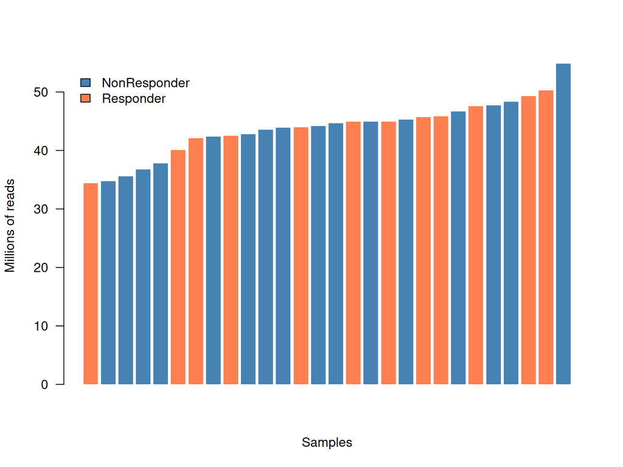

Figure 1: Barplot of sequencing depth (millions of reads) per sample, ordered by library size  
Colors indicate dasatinib response status.

```r
ord <- order(dge$samples$lib.size)
barplot(
  dge$samples$lib.size[ord] / 1e6,
  las   = 1,
  ylab  = "Millions of reads",
  xlab  = "Samples",
  col   = c("steelblue", "coral")[cll$response2[ord]],
  border = NA
)
legend("topleft",
       c("NonResponder", "Responder"),
       fill = c("steelblue", "coral"),
       inset = 0.01, bty = "n")
```

## 3.3 Distribution of Expression Levels

We compute log₂-CPM values and examine their distribution across samples. Consistent distributions indicate that RNA composition is similar and no single sample is an outlier.

```r
# Compute logCPM using edgeR (prior.count adds a small pseudocount to avoid log(0))
logCPM <- cpm(dge, log = TRUE, prior.count = 0.25)

# Store in the SummarizedExperiment for later use
assays(cll, withDimnames = FALSE)$logCPM <- logCPM
```

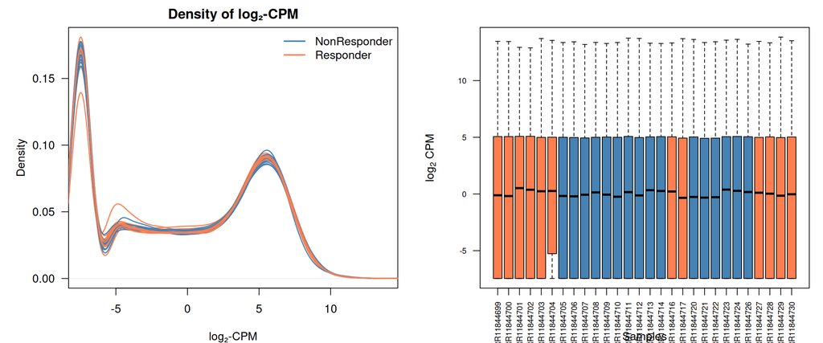

Figure 2: Distribution of normalized gene expression values  
Left: Kernel density plots of log₂-CPM per sample. Right: Boxplots of log₂-CPM values per sample.

```r
par(mfrow = c(1, 2), mar = c(4, 5, 2, 1))

# Density plot
cols <- ifelse(cll$response2 == "Responder", "coral", "steelblue")
plot(density(logCPM[, 1]), main = "Density of log₂-CPM", xlab = "log₂-CPM",
     ylab = "Density", las = 1, xlim = range(logCPM),
     ylim = c(0, max(sapply(1:ncol(logCPM), function(i) max(density(logCPM[, i])$y)))),
     col = cols[1], lwd = 1.5)
for (i in 2:ncol(logCPM)) {
  lines(density(logCPM[, i]), col = cols[i], lwd = 1.5)
}
legend("topright", c("NonResponder", "Responder"),
       col = c("steelblue", "coral"), lwd = 2, bty = "n")

# Boxplot
boxplot(logCPM, col = cols, xlab = "Samples",
        ylab = expression(log[2] * " CPM"), las = 2, cex.axis = 0.7)
```

## 3.4 Filtering Lowly Expressed Genes

**Theory: Why filter?**

Lowly expressed genes contribute noise to downstream analyses. They increase the multiple testing burden (more genes tested = more stringent FDR correction) and can introduce artifacts in dispersion estimation. The standard approach is to remove genes that are not expressed at a biologically meaningful level in enough samples.

**Two filtering strategies compared:**

1. `filterByExpr()` (edgeR built-in) - uses the design matrix to determine the minimum count threshold automatically. It requires a gene to have at least ~10 counts in the smallest group.
2. **Manual CPM threshold** - we require CPM > cutoff in at least *n* samples, where *n* equals the size of the smallest group. The cutoff adapts to library size: `10 / min(lib.size/1e6)`.

We use both and compare.

```r
# Strategy 1: filterByExpr (recommended, design-aware)
mask_fbe <- filterByExpr(dge, group = dge$samples$response2)
cat("filterByExpr retains:", sum(mask_fbe), "of", nrow(dge), "genes\n")
filterByExpr retains: 14685 of 25120 genes
```

```r
# Strategy 2: Manual CPM-based threshold
cpmcutoff <- round(10 / min(dge$samples$lib.size / 1e6), digits = 1)
nsamplescutoff <- min(table(cll$response2))
mask_cpm <- rowSums(cpm(dge) > cpmcutoff) >= nsamplescutoff
cat("Manual CPM (>", cpmcutoff, "in >=", nsamplescutoff, "samples) retains:",
    sum(mask_cpm), "genes\n")
Manual CPM (> 0.3 in >= 12 samples) retains: 14295 genes
```

```r
# We use filterByExpr as our primary filter (more principled)
dge.filt <- dge[mask_fbe, , keep.lib.sizes = FALSE]
cll.filt <- cll[mask_fbe, ]

cat("\nAfter filtering:", nrow(dge.filt), "genes retained for analysis\n")

After filtering: 14685 genes retained for analysis
```

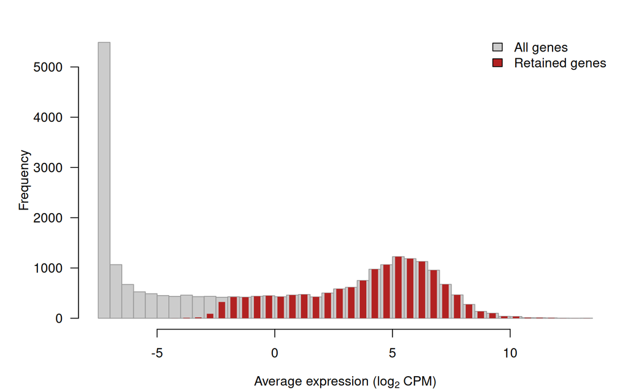

Figure 3: Distribution of average gene expression before and after filtering  
Red bars indicate genes retained after filtering.

```r
avgexp <- rowMeans(logCPM)
par(mar = c(4, 5, 2, 1))
h <- hist(avgexp, breaks = 50,
          xlab = expression("Average expression (log"[2] * " CPM)"),
          main = "", las = 1, col = "grey80", border = "grey60")

# Overlay retained genes
avgexp_filt <- rowMeans(logCPM[mask_fbe, ])
x <- cut(avgexp_filt, breaks = h$breaks)
lines(h$mids, table(x), type = "h", lwd = 8, lend = 1, col = "firebrick")
legend("topright", c("All genes", "Retained genes"),
       fill = c("grey80", "firebrick"), bty = "n")
```

# 4 Normalization

## 4.1 TMM Normalization

**Theory: Why normalize?**

Raw library sizes differ between samples due to sequencing depth variation. But simply dividing by total counts (CPM) doesn’t account for **RNA composition bias** - the situation where a few highly expressed genes in one sample consume a disproportionate share of the sequencing reads, making all other genes appear relatively under-expressed.

**TMM (Trimmed Mean of M-values)** addresses this by computing a scaling factor that adjusts for both library size and RNA composition. It works by selecting a reference sample, computing log-fold changes (M-values) and absolute expression levels (A-values) for each gene relative to the reference, trimming the extreme values (top/bottom 30% of M-values and 5% of A-values), and taking the weighted mean of the remaining M-values. The resulting normalization factor is applied to the effective library size.

A normalization factor close to 1 means the sample’s RNA composition is similar to the reference; factors substantially different from 1 indicate compositional bias that TMM corrects.

```r
dge.filt <- calcNormFactors(dge.filt, method = "TMM")

cat("TMM normalization factors:\n")
TMM normalization factors:
print(round(dge.filt$samples$norm.factors, 4))
 [1] 0.9995 0.9708 1.0703 1.0547 0.9933 0.9912 1.0023 0.9809 1.0009 0.9821
[11] 1.0442 1.0178 1.0273 0.9199 1.0227 1.0168 0.9903 0.9442 0.9816 0.9866
[21] 0.9891 1.0613 1.0537 1.0125 0.9852 0.9977 0.9378 0.9827
cat("\nSummary:\n")

Summary:
summary(dge.filt$samples$norm.factors)
   Min. 1st Qu.  Median    Mean 3rd Qu.    Max.
 0.9199  0.9825  0.9955  1.0006  1.0190  1.0703
```

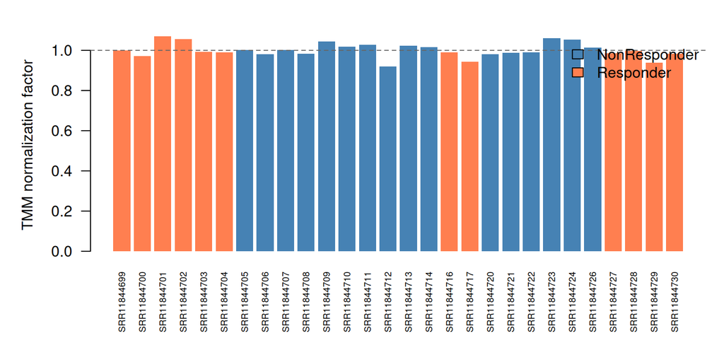

Figure 4: TMM normalization factors per sample  
Values close to 1 indicate balanced RNA composition.

```r
par(mar = c(6, 5, 2, 1))
barplot(dge.filt$samples$norm.factors,
        names.arg = colnames(dge.filt),
        las = 2, cex.names = 0.6,
        ylab = "TMM normalization factor",
        col = c("steelblue", "coral")[cll.filt$response2],
        border = NA)
abline(h = 1, lty = 2, col = "gray40")
legend("topright", c("NonResponder", "Responder"),
       fill = c("steelblue", "coral"), bty = "n")
```

# 5 Exploratory Data Analysis

## 5.1 MA Plots (Per-Sample)

MA plots show the relationship between average expression (A) and log-fold change (M) for each sample relative to the global mean. A well-normalized sample shows M-values symmetrically distributed around zero, with the lowess curve flat.

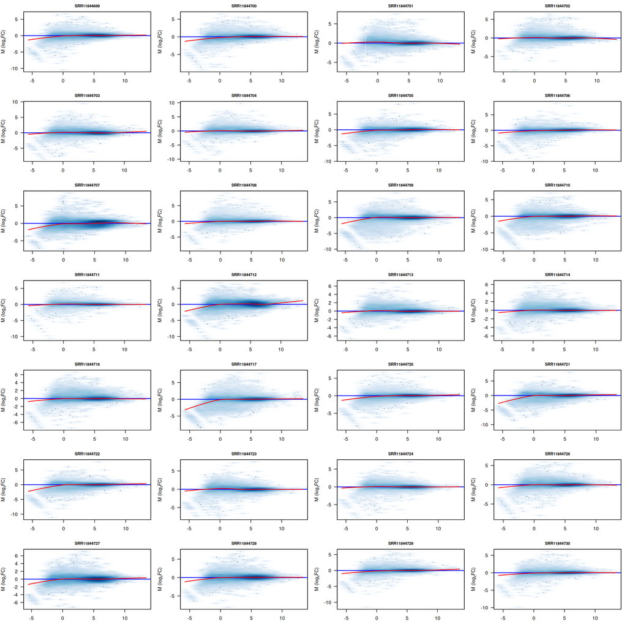

Figure 5: MA plots for all samples after TMM normalization  
Each panel shows one sample’s log-fold change relative to the dataset mean. Red lowess curves should track the blue y=0 baseline.

```r
logcpm_filt <- cpm(dge.filt, log = TRUE, prior.count = 0.25)
n_samples <- ncol(logcpm_filt)
par(mfrow = c(ceiling(n_samples / 4), 4), mar = c(3, 4, 2, 1))

for (i in 1:n_samples) {
  avg_others <- rowMeans(logcpm_filt[, -i, drop = FALSE])
  M <- logcpm_filt[, i] - avg_others
  A <- (logcpm_filt[, i] + avg_others) / 2
  smoothScatter(A, M, main = colnames(logcpm_filt)[i], las = 1,
                xlab = "", ylab = "M (log₂FC)", cex.main = 0.8)
  abline(h = 0, col = "blue", lwd = 1.5)
  lines(lowess(A, M, f = 0.3), col = "red", lwd = 1.5)
}
```

```r
par(mfrow = c(1, 1))
```

## 5.2 MDS Plot (Multidimensional Scaling)

**Theory: What is MDS?**

MDS (Multidimensional Scaling) reduces high-dimensional gene expression data into 2D by preserving the distances between samples. In edgeR, `plotMDS()` uses **leading log-fold change** distances - the root mean square of the largest log-fold changes between each pair of samples. This makes it more robust than PCA for count data because it focuses on the genes that most differ between samples rather than the highest- variance genes (which may be dominated by highly expressed housekeeping genes).

The resulting plot reveals whether samples cluster by biological condition (responder vs. non-responder), by batch, or by other covariates.

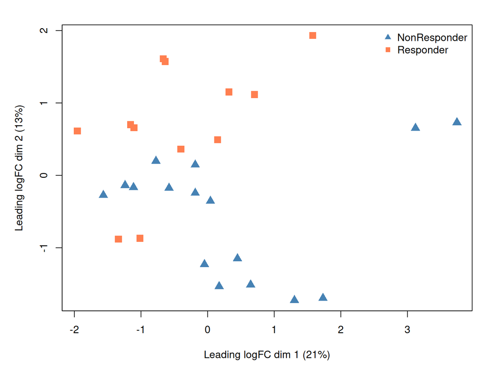

```r
par(mar = c(5, 5, 2, 2))
col_response <- c("steelblue", "coral")[as.numeric(cll.filt$response2)]
pch_response <- c(17, 15)[as.numeric(cll.filt$response2)]

plotMDS(dge.filt, col = col_response, pch = pch_response, cex = 1.5)
legend("topright",
       legend = levels(cll.filt$response2),
       col = c("steelblue", "coral"),
       pch = c(17, 15), bty = "n")
```

## 5.3 Hierarchical Clustering

We use Spearman correlation-based hierarchical clustering to confirm the MDS findings and assess whether samples cluster by response status or batch.

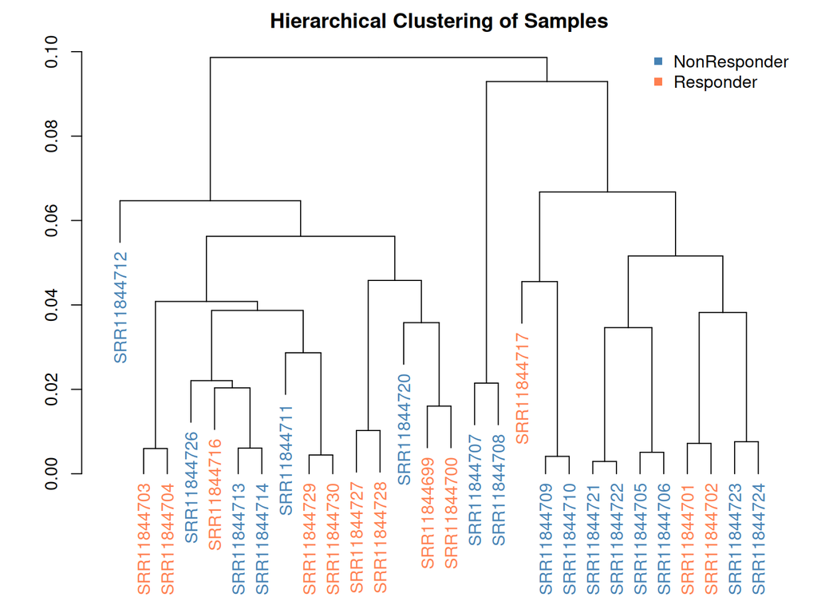

Figure 7: Hierarchical clustering dendrogram of samples based on Spearman correlation of log₂-CPM expression profiles  
Leaf colors indicate response status.

```r
d <- as.dist(1 - cor(logcpm_filt, method = "spearman"))
hc <- hclust(d)
dend <- as.dendrogram(hc, hang = 0.1)

# Color leaves by response status
labfun <- function(x, response_vec) {
  if (is.leaf(x)) {
    lab <- attr(x, "label")
    col <- ifelse(response_vec[lab] == "Responder", "coral", "steelblue")
    attr(x, "nodePar") <- list(lab.col = col, pch = NA)
  }
  x
}

response_named <- setNames(as.character(cll.filt$response2), colnames(cll.filt))
dend <- dendrapply(dend, labfun, response_named)
par(mar = c(6, 4, 2, 1))
plot(dend, main = "Hierarchical Clustering of Samples")
legend("topright", c("NonResponder", "Responder"),
       col = c("steelblue", "coral"), pch = 15, bty = "n")
```

## 5.4 Batch Effect Assessment

**Theory: Confounding and batch effects**

Batch effects are systematic technical differences between groups of samples processed at different times, on different instruments, or by different technicians. If batches are confounded with the biological variable of interest (e.g., all responders processed in batch 1, all non-responders in batch 2), we cannot distinguish biological from technical effects. If they are not confounded, we can include batch as a covariate in our linear model to adjust for it.

We check for confounding by examining contingency tables between response status and available metadata variables.

```r
# Check which metadata columns could be batch indicators
cat("Available metadata columns:\n")
Available metadata columns:
cat(colnames(colData(cll.filt)), sep = "\n")
title
geo_accession
status
submission_date
last_update_date
type
channel_count
source_name_ch1
organism_ch1
characteristics_ch1
characteristics_ch1.1
characteristics_ch1.2
characteristics_ch1.3
characteristics_ch1.4
characteristics_ch1.5
characteristics_ch1.6
molecule_ch1
extract_protocol_ch1
extract_protocol_ch1.1
taxid_ch1
description
description.1
description.2
description.3
description.4
data_processing
data_processing.1
data_processing.2
data_processing.3
data_processing.4
platform_id
data_row_count
instrument_model
library_selection
library_source
library_strategy
relation
relation.1
supplementary_file_1
batch:ch1
cell type:ch1
in vitro dasatinib treatment:ch1
patient diagnosis:ch1
patient id:ch1
patient's in vitro response to dasatinib:ch1
unified patient id, as used in the manuscript:ch1
response2

# Check for confounding between response and treatment status
cat("\n\nResponse vs. Treatment status:\n")


Response vs. Treatment status:
if ("characteristics_ch1.3" %in% colnames(colData(cll.filt))) {
  print(table(cll.filt$response2, cll.filt$characteristics_ch1.3))
}

               in vitro dasatinib treatment: no
  NonResponder                                9
  Responder                                   6

               in vitro dasatinib treatment: yes
  NonResponder                                 7
  Responder                                    6
```

# 6 Surrogate Variable Analysis (SVA)

**Theory: What is SVA?**

Even when no explicit batch information is available, hidden sources of variation (unknown batches, sample handling differences, RNA quality) can inflate false positives. **Surrogate Variable Analysis (SVA)** estimates these hidden factors from the data itself, creating “surrogate variables” (SVs) that capture systematic unwanted variation. These SVs can then be included in the linear model as covariates, effectively adjusting for unknown batch effects without needing to identify their source.

SVA uses a two-step approach:

1. **Identify the number of significant surrogate variables** using `num.sv()` (or the BE method).
2. **Estimate the surrogate variables** using `sva()`, which distinguishes signal (driven by the primary variable of interest) from noise (driven by hidden factors).

```r
# Prepare the model matrices
mod <- model.matrix(~ response2, data = colData(cll.filt))
mod0 <- model.matrix(~ 1, data = colData(cll.filt))

# Estimate number of surrogate variables
n_sv <- num.sv(logcpm_filt, mod, method = "be")
cat("Estimated number of surrogate variables:", n_sv, "\n")
Estimated number of surrogate variables: 8

# Estimate surrogate variables (if any detected)
if (n_sv > 0) {
  sva_obj <- sva(logcpm_filt, mod, mod0, n.sv = n_sv)
  cat("SVA completed. Surrogate variables estimated:", ncol(sva_obj$sv), "\n")

  # Store SVs for use in the design matrix
  sv_df <- as.data.frame(sva_obj$sv)
  colnames(sv_df) <- paste0("SV", 1:ncol(sv_df))
} else {
  cat("No significant surrogate variables detected.\n")
  sv_df <- NULL
}
Number of significant surrogate variables is:  8
Iteration (out of 5 ):1  2  3  4  5  SVA completed. Surrogate variables estimated: 8
```

# 7 Differential Expression Analysis

## 7.1 Constructing the Design Matrix

**Theory: Design matrices in limma**

The design matrix tells limma how to model the data. We use a **cell-means model** (`~ 0 + response2`), where each coefficient represents the mean expression of a group rather than the difference from a reference. This makes it straightforward to define any contrast we want using `makeContrasts()`.

If SVA detected surrogate variables, we include them in the design matrix to adjust for hidden confounders.

```r
# Build design matrix with or without surrogate variables
if (!is.null(sv_df)) {
  design_df <- cbind(colData(cll.filt)[, "response2", drop = FALSE], sv_df)
  design_formula <- as.formula(paste("~ 0 + response2 +",
                                      paste(colnames(sv_df), collapse = " + ")))
  design <- model.matrix(design_formula, data = design_df)
  cat("Design matrix includes response2 +", ncol(sv_df), "surrogate variables\n")
} else {
  design <- model.matrix(~ 0 + response2, data = colData(cll.filt))
  cat("Design matrix includes response2 only (no SVs detected)\n")
}
Design matrix includes response2 + 8 surrogate variables

cat("\nDesign matrix columns:", colnames(design), "\n")

Design matrix columns: response2NonResponder response2Responder SV1 SV2 SV3 SV4 SV5 SV6 SV7 SV8
cat("Dimensions:", nrow(design), "samples x", ncol(design), "coefficients\n")
Dimensions: 28 samples x 10 coefficients
```

## 7.2 Voom Transformation

**Theory: What does voom() do?**

RNA-seq count data has a characteristic **mean-variance relationship**: genes with higher average expression tend to have higher variance (this is called heteroscedasticity). Standard linear models assume constant variance (homoscedasticity), so raw or log-transformed counts violate this assumption.

`voom()` solves this by:

1. Computing log₂-CPM values from the DGEList
2. Fitting a linear model to estimate the mean expression of each gene
3. Computing the residuals and estimating the variance at each expression level (the **mean-variance trend**)
4. Generating **precision weights** for each observation based on this trend - observations with higher predicted variance get lower weight

The output is an `EList` object with `$E` (log₂-CPM), `$weights` (precision weights), and `$design` (design matrix). This weighted data can then be analyzed using standard limma functions.

The mean-variance trend plot is diagnostic: a smooth, decreasing curve indicates that the transformation is working correctly. A flat or erratic trend suggests issues with the data or filtering.

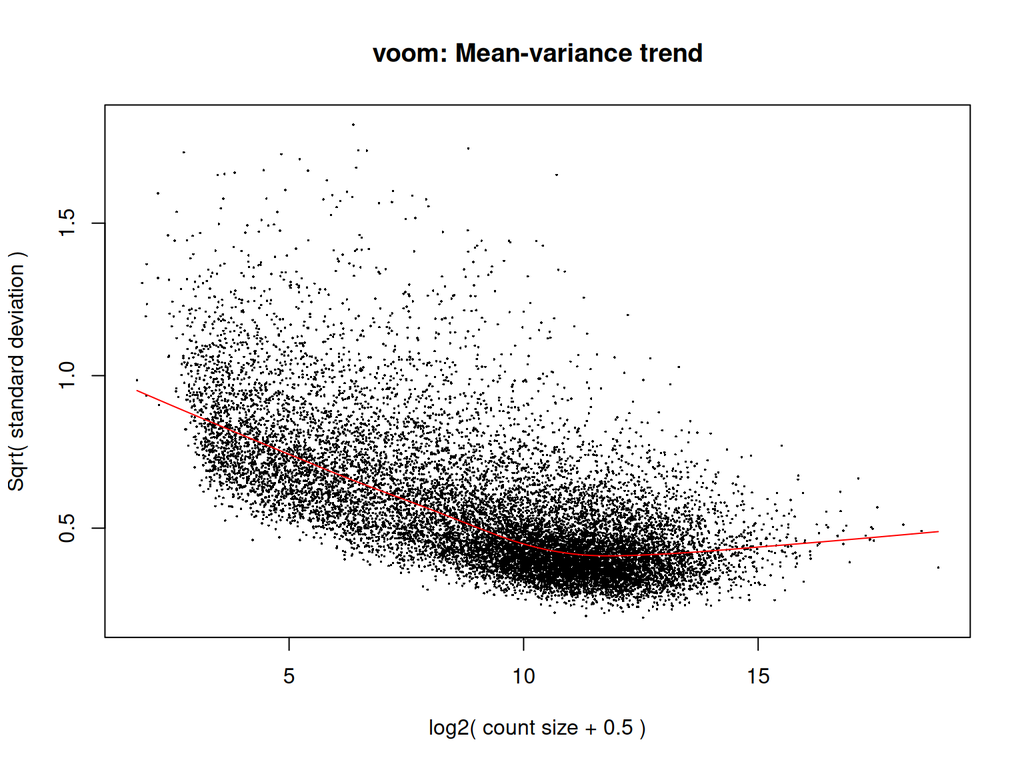

```r
v <- voom(dge.filt, design, plot = TRUE)
```

## 7.3 Fitting the Linear Model

**Theory: lmFit + eBayes**

`lmFit()` fits a separate weighted linear model for each gene using the design matrix and precision weights from voom. Each gene gets its own set of coefficients (one per design column) and residual variance.

`eBayes()` then applies **empirical Bayes moderation** - it “borrows strength” across genes by shrinking each gene’s variance estimate toward a common prior. This is critical because with only ~12-16 samples per group, individual gene variance estimates are noisy. By pooling information across all genes, eBayes produces **moderated t-statistics** that are more stable than ordinary t-statistics, leading to better ranking of genes and improved power for detecting true DE.

```r
fit <- lmFit(v, design)
```

## 7.4 Defining Contrasts

We define the contrast of interest: **Responder vs. NonResponder**. A positive log₂FC means the gene is more highly expressed in responders.

```r
contrast_matrix <- makeContrasts(
  Responder_vs_NonResponder = response2Responder - response2NonResponder,
  levels = design
)

cat("Contrast matrix:\n")
Contrast matrix:
print(contrast_matrix)
                       Contrasts
Levels                  Responder_vs_NonResponder
  response2NonResponder                        -1
  response2Responder                            1
  SV1                                           0
  SV2                                           0
  SV3                                           0
  SV4                                           0
  SV5                                           0
  SV6                                           0
  SV7                                           0
  SV8                                           0

# Apply contrast and compute moderated statistics
fit2 <- contrasts.fit(fit, contrast_matrix)
fit2 <- eBayes(fit2)
```

## 7.5 Extracting Results

```r
# Full results table
tt <- topTable(fit2, coef = "Responder_vs_NonResponder",
               number = Inf, sort.by = "P")

cat("Total genes tested:", nrow(tt), "\n")
Total genes tested: 14685
cat("Genes with FDR < 0.05:", sum(tt$adj.P.Val < 0.05), "\n")
Genes with FDR < 0.05: 2486
cat("Genes with FDR < 0.01:", sum(tt$adj.P.Val < 0.01), "\n")
Genes with FDR < 0.01: 876
```

```r
# Define strict thresholds
strict_fdr   <- 0.05
min_abs_logFC <- 1.0  # |log₂FC| >= 1 means at least 2-fold change

strict_DEGs <- tt %>%
  rownames_to_column(var = "ensembl_id") %>%
  filter(adj.P.Val < strict_fdr, abs(logFC) >= min_abs_logFC)

cat("Strict DEGs (FDR <", strict_fdr, "and |log₂FC| >=", min_abs_logFC, "):",
    nrow(strict_DEGs), "\n")
Strict DEGs (FDR < 0.05 and |log₂FC| >= 1 ): 310
cat("  Upregulated in Responders:  ", sum(strict_DEGs$logFC > 0), "\n")
  Upregulated in Responders:   199
cat("  Downregulated in Responders:", sum(strict_DEGs$logFC < 0), "\n")
  Downregulated in Responders: 111
```

# 8 Visualization of DE Results

## 8.1 P-value Distribution

**Theory: Interpreting p-value histograms**

A well-calibrated DE analysis should produce a p-value distribution that is a mixture of:

- A **uniform component** (from true null genes, ~horizontal line)
- A **spike near zero** (from truly DE genes)

If the histogram shows an anti-conservative pattern (spike near 1), it may indicate issues with the model or confounding. If it’s perfectly uniform with no spike near zero, there may be no true signal.

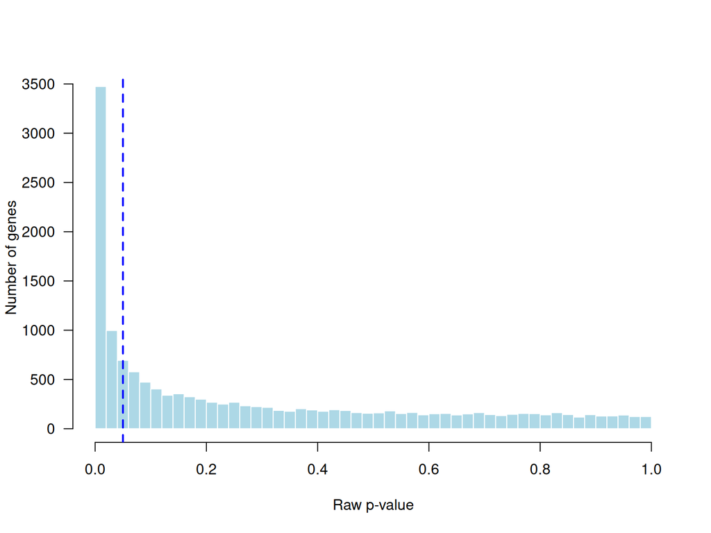

Figure 9: Distribution of raw p-values  
A clear enrichment near zero indicates true differential expression signal above the uniform null.

```r
hist(tt$P.Value, breaks = 50, col = "lightblue", border = "white",
     main = "", xlab = "Raw p-value", ylab = "Number of genes", las = 1)
abline(v = 0.05, col = "blue", lwd = 2, lty = 2)
text(0.3, max(hist(tt$P.Value, plot = FALSE)$counts) * 0.9,
     paste0("Genes with p ≤ 0.05: ", sum(tt$P.Value <= 0.05)),
     col = "blue", font = 2, cex = 0.9)
```

## 8.2 Volcano Plot

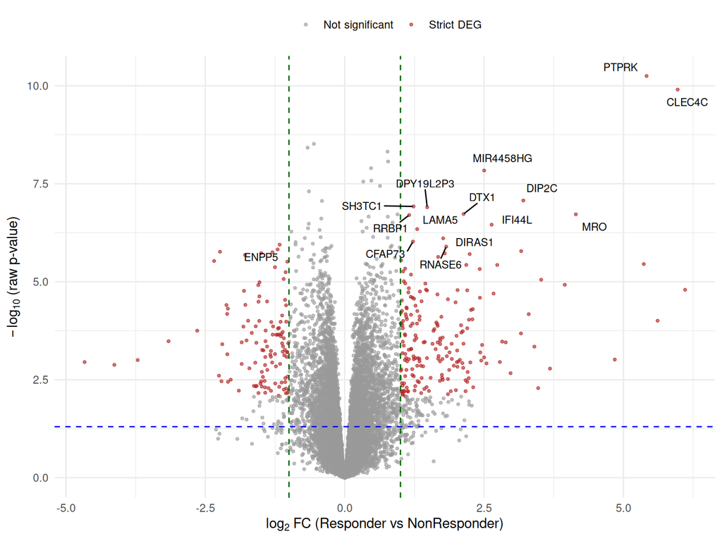

Figure 10: Volcano plot of log₂ fold changes vs. −log₁₀ raw p-values  
Red points are strict DEGs (FDR < 0.05 and |log₂FC| ≥ 1). Top genes are labeled.

```r
volcano_df <- data.frame(
  logFC     = tt$logFC,
  negLogP   = -log10(tt$P.Value),
  adj.P.Val = tt$adj.P.Val,
  symbol    = tt$symbol,
  is_strict = tt$adj.P.Val < strict_fdr & abs(tt$logFC) >= min_abs_logFC
)

# Select top genes to label (top 10 by significance among strict DEGs)
top_to_label <- volcano_df %>%
  filter(is_strict) %>%
  arrange(adj.P.Val) %>%
  slice_head(n = 15)

ggplot(volcano_df, aes(x = logFC, y = negLogP)) +
  geom_point(aes(color = is_strict), size = 0.8, alpha = 0.6) +
  scale_color_manual(values = c("grey60", "firebrick"),
                     labels = c("Not significant", "Strict DEG")) +
  geom_vline(xintercept = c(-min_abs_logFC, min_abs_logFC),
             linetype = "dashed", color = "darkgreen", linewidth = 0.5) +
  geom_hline(yintercept = -log10(0.05),
             linetype = "dashed", color = "blue", linewidth = 0.5) +
  geom_text_repel(data = top_to_label,
                  aes(label = symbol), size = 3,
                  max.overlaps = 20, box.padding = 0.4) +
  labs(x = expression(log[2] ~ "FC (Responder vs NonResponder)"),
       y = expression(-log[10] ~ "(raw p-value)"),
       color = "") +
  theme_minimal() +
  theme(legend.position = "top")
```

## 8.3 Heatmap of Top DEGs

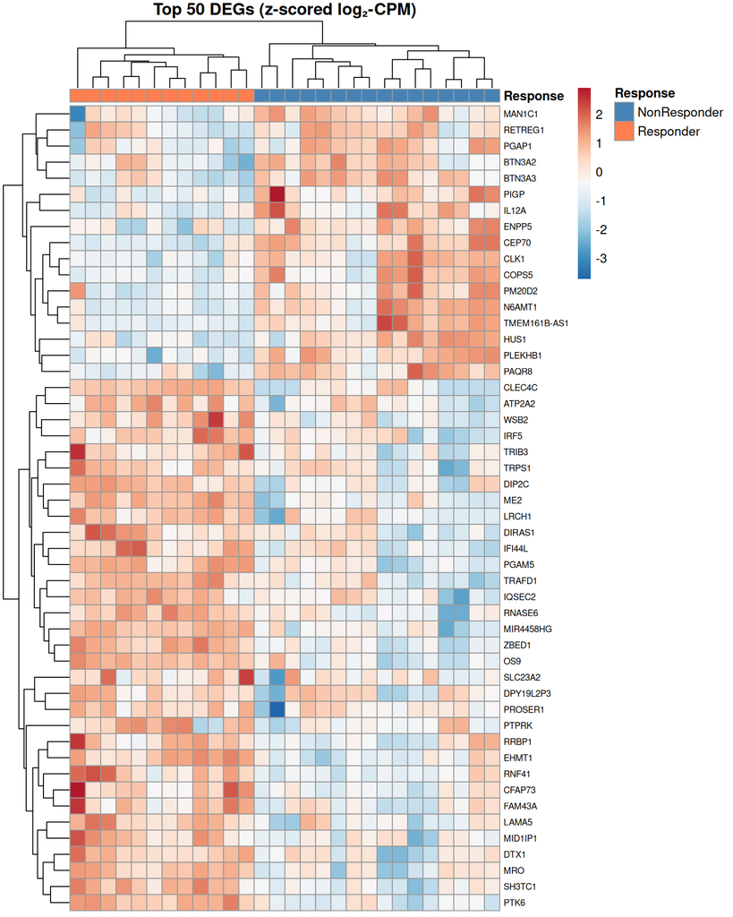

Figure 11: Heatmap of the top 50 DEGs ranked by adjusted p-value  
Rows are genes (z-scored), columns are samples. Annotation bars show response status.

```r
# Select top 50 genes by adjusted p-value
top50 <- head(tt, 50)
top50_ids <- rownames(top50)

# Extract logCPM for these genes and z-score across samples
mat <- logcpm_filt[top50_ids, ]
mat_z <- t(scale(t(mat)))

# Annotation
annot_col <- data.frame(
  Response = cll.filt$response2,
  row.names = colnames(mat_z)
)
annot_colors <- list(
  Response = c(NonResponder = "steelblue", Responder = "coral")
)

# Use gene symbols as row labels where available
rownames(mat_z) <- ifelse(is.na(top50$symbol) | top50$symbol == "",
                          rownames(mat_z), top50$symbol)

pheatmap(mat_z,
         annotation_col = annot_col,
         annotation_colors = annot_colors,
         cluster_rows = TRUE, cluster_cols = TRUE,
         show_colnames = FALSE,
         fontsize_row = 7,
         color = colorRampPalette(rev(brewer.pal(9, "RdBu")))(100),
         main = "Top 50 DEGs (z-scored log₂-CPM)")
```

## 8.4 Top 20 DEGs Table

```r
top20_table <- strict_DEGs %>%
  arrange(desc(abs(logFC))) %>%
  slice_head(n = 20) %>%
  dplyr::select(ensembl_id, gene_biotype, symbol, logFC,
                AveExpr, t, P.Value, adj.P.Val) %>%
  rename(
    "Gene ID"     = ensembl_id,
    "Biotype"     = gene_biotype,
    "Symbol"      = symbol,
    "log₂FC"      = logFC,
    "Avg log₂CPM" = AveExpr,
    "t-statistic"  = t,
    "P-value"      = P.Value,
    "FDR"          = adj.P.Val
  )

kable(top20_table,
      caption = "Top 20 DEGs ranked by absolute fold change (FDR < 0.05, |log₂FC| ≥ 1).",
      digits = c(NA, NA, NA, 3, 3, 3, 5, 5),
      row.names = FALSE) %>%
  kable_styling(full_width = FALSE, position = "center",
                bootstrap_options = c("striped", "hover", "condensed")) %>%
  scroll_box(width = "100%", height = "400px")
```

Table 1: Table 2: Top 20 DEGs ranked by absolute fold change (FDR < 0.05, |log₂FC| ≥ 1).

| Gene ID | Biotype | Symbol | log₂FC | Avg log₂CPM | t-statistic | P-value | FDR |
| --- | --- | --- | --- | --- | --- | --- | --- |
| 153579 | protein_coding | BTNL9 | 6.106 | -0.925 | 5.554 | 0.00002 | 0.00135 |
| 170482 | protein_coding | CLEC4C | 5.972 | -0.710 | 11.600 | 0.00000 | 0.00000 |
| 63934 | protein_coding | ZNF667 | 5.613 | 0.360 | 4.782 | 0.00010 | 0.00362 |
| 5796 | protein_coding | PTPRK | 5.414 | -0.051 | 12.111 | 0.00000 | 0.00000 |
| 5101 | protein_coding | PCDH9 | 5.365 | 3.871 | 6.214 | 0.00000 | 0.00062 |
| 63898 | protein_coding | SH2D4A | 4.844 | -1.604 | 3.829 | 0.00097 | 0.01328 |
| 643680 | protein_coding | MS4A4E | -4.666 | 0.794 | -3.767 | 0.00112 | 0.01443 |
| 83876 | protein_coding | MRO | 4.146 | -0.166 | 7.567 | 0.00000 | 0.00015 |
| 150094 | protein_coding | SIK1 | -4.132 | -0.982 | -3.699 | 0.00132 | 0.01601 |
| 57573 | protein_coding | ZNF471 | 3.947 | 1.996 | 5.681 | 0.00001 | 0.00115 |
| 10753 | protein_coding | CAPN9 | -3.714 | -1.898 | -3.818 | 0.00099 | 0.01354 |
| 10687 | protein_coding | PNMA2 | 3.682 | 1.772 | 3.605 | 0.00165 | 0.01861 |
| 4023 | protein_coding | LPL | 3.524 | 2.873 | 5.809 | 0.00001 | 0.00101 |
| 7483 | protein_coding | WNT9A | 3.470 | 1.031 | 3.117 | 0.00518 | 0.03709 |
| 1821 | protein_coding | DRP2 | 3.402 | 0.556 | 4.145 | 0.00045 | 0.00855 |
| 65975 | protein_coding | STK33 | 3.299 | -0.408 | 4.944 | 0.00007 | 0.00296 |
| 22982 | protein_coding | DIP2C | 3.204 | 3.098 | 7.963 | 0.00000 | 0.00009 |
| 400617 | antisense_RNA | KCNJ2-AS1 | 3.165 | -2.505 | 6.556 | 0.00000 | 0.00043 |
| 200150 | protein_coding | PLD5 | 3.161 | -1.051 | 4.469 | 0.00021 | 0.00548 |
| 11086 | protein_coding | ADAM29 | -3.160 | 0.507 | -4.278 | 0.00033 | 0.00707 |

## 8.5 Save DE Results

```r
# Save full results
#write.csv(tt, "../results/tables/p1_full_DE_results.csv", row.names = TRUE)

# Save strict DEGs
#write.csv(strict_DEGs, "../results/tables/p1_strict_DEGs.csv", row.names = FALSE)

#cat("Saved full DE results and strict DEGs to results/tables/\n")
```

# 9 Functional Enrichment Analysis

## 9.1 Gene Ontology (GO) Enrichment with GOstats

**Theory: Hypergeometric test for GO enrichment**

Gene Ontology (GO) enrichment asks: among our list of DE genes, are certain biological processes (BP), molecular functions (MF), or cellular components (CC) over-represented compared to what we would expect by chance?

The hypergeometric test (Fisher’s exact test) models this as drawing balls from an urn: given *N* total genes, *K* genes annotated to a GO term, and *n* DE genes, how many DE genes annotated to that term (*k*) would we expect? A significant p-value means the overlap is larger than chance.

The **conditional test** (`conditional(params) <- TRUE`) accounts for the hierarchical structure of GO by conditioning on child terms that have already been found significant, reducing redundancy.

```r
# GOstats requires Entrez IDs - our gene identifiers are Ensembl
# We use the strict DEGs Ensembl IDs
params <- new("GOHyperGParams",
              geneIds     = strict_DEGs$ensembl_id,
              annotation  = "org.Hs.eg.db",
              ontology    = "BP",
              pvalueCutoff = 0.05,
              testDirection = "over")

conditional(params) <- TRUE
hgOverCond <- hyperGTest(params)

# Summarize and filter results
resGO <- summary(hgOverCond)
resGO <- resGO[resGO$Size >= 3 & resGO$Size <= 300 & resGO$Count >= 3, ]
resGO <- resGO[order(resGO$OddsRatio, decreasing = TRUE), ]

cat("Significant GO BP terms after filtering:", nrow(resGO), "\n")
Significant GO BP terms after filtering: 101
```

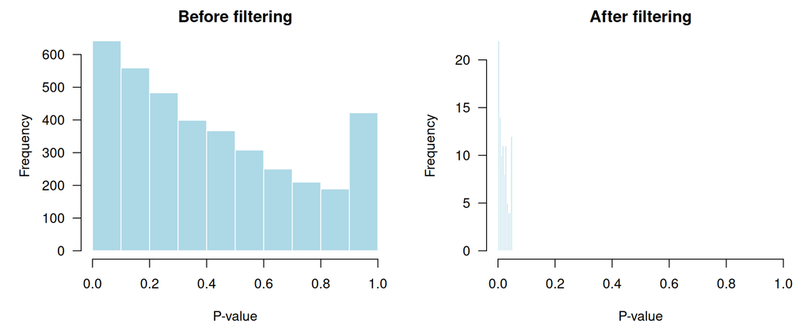

Figure 12: P-value distributions for GO enrichment before and after filtering by term size and gene count

```r
pvals_all <- pvalues(hgOverCond)
par(mfrow = c(1, 2), mar = c(4, 5, 2, 1))
hist(pvals_all, xlab = "P-value", main = "Before filtering", las = 1,
     col = "lightblue", border = "white")
hist(pvals_all[resGO$GOBPID], xlab = "P-value", main = "After filtering",
     las = 1, col = "lightblue", border = "white", xlim = c(0, 1))
```

```r
# Map Entrez IDs to gene symbols for each GO term
geneIDs_by_GO <- geneIdsByCategory(hgOverCond)[resGO$GOBPID]
entrez_ids <- unique(as.character(unlist(geneIDs_by_GO)))

entrez_to_symbol <- AnnotationDbi::select(
  org.Hs.eg.db,
  keys = entrez_ids,
  columns = "SYMBOL",
  keytype = "ENTREZID"
)
sym_map <- setNames(entrez_to_symbol$SYMBOL, entrez_to_symbol$ENTREZID)

gene_symbols_by_go <- sapply(geneIDs_by_GO, function(ids) {
  syms <- sym_map[as.character(ids)]
  paste(syms[!is.na(syms)], collapse = ", ")
})

go_results <- cbind(resGO, Genes = unlist(gene_symbols_by_go))
rownames(go_results) <- 1:nrow(go_results)
```

```r
kable(head(go_results, 15),
      caption = "Top 15 enriched GO Biological Process terms.",
      row.names = FALSE) %>%
  kable_styling(full_width = FALSE, position = "center",
                bootstrap_options = c("striped", "hover", "condensed")) %>%
  scroll_box(width = "100%", height = "400px")
```

Table 3: Table 4: Top 15 enriched GO Biological Process terms.

| GOBPID | Pvalue | OddsRatio | ExpCount | Count | Size | Term | Genes |
| --- | --- | --- | --- | --- | --- | --- | --- |
| GO:0030185 | 0.0000262 | 107.336539 | 0.0696873 | 3 | 5 | nitric oxide transport | HBA1, HBA2, HBB |
| GO:0015670 | 0.0010758 | 17.879808 | 0.2090620 | 3 | 15 | carbon dioxide transport | HBA1, HBA2, HBB |
| GO:0015671 | 0.0010758 | 17.879808 | 0.2090620 | 3 | 15 | oxygen transport | HBA1, HBA2, HBB |
| GO:0048535 | 0.0018706 | 14.301538 | 0.2508744 | 3 | 18 | lymph node development | PDPN, IL15, TOX |
| GO:0099563 | 0.0005802 | 11.958172 | 0.3902491 | 4 | 28 | modification of synaptic structure | SYNPO, ITPKA, CTTNBP2, ARHGAP44 |
| GO:0010839 | 0.0043626 | 10.212088 | 0.3344992 | 3 | 24 | negative regulation of keratinocyte proliferation | PTCH1, PTPRK, EPPK1 |
| GO:0034260 | 0.0043626 | 10.212088 | 0.3344992 | 3 | 24 | negative regulation of GTPase activity | DAB2IP, SH3BP4, PLXNB3 |
| GO:0014829 | 0.0054905 | 9.323077 | 0.3623741 | 3 | 26 | vascular associated smooth muscle contraction | EDNRB, P2RX1, CD38 |
| GO:1901381 | 0.0016966 | 8.692641 | 0.5156863 | 4 | 37 | positive regulation of potassium ion transmembrane transport | ANK2, KCNH2, KCNJ2, FXYD2 |
| GO:0086091 | 0.0018757 | 8.436521 | 0.5296237 | 4 | 38 | regulation of heart rate by cardiac conduction | ANK2, KCNH2, KCNJ2, TRPM4 |
| GO:0042744 | 0.0090197 | 7.656181 | 0.4320615 | 3 | 31 | hydrogen peroxide catabolic process | HBA1, HBA2, HBB |
| GO:0010765 | 0.0098518 | 7.391777 | 0.4459989 | 3 | 32 | positive regulation of sodium ion transport | DMD, FXYD2, TESC |
| GO:0099171 | 0.0098518 | 7.391777 | 0.4459989 | 3 | 32 | presynaptic modulation of chemical synaptic transmission | HIP1, APBA2, NOG |
| GO:0046330 | 0.0000314 | 7.265490 | 1.2264971 | 8 | 88 | positive regulation of JNK cascade | EDAR, DAB2IP, APP, SERPINF2, EDA2R, CARD9, SLAMF1, MFHAS1 |
| GO:1990573 | 0.0038016 | 6.826623 | 0.6411235 | 4 | 46 | potassium ion import across plasma membrane | SLC12A7, KCNH2, KCNJ2, FXYD2 |